# Saqrlab Reference — Item Response Theory

This reference covers `simulate_irt()`, which generates item-response data under a known Item Response Theory model with ground-truth item and person parameters. It supports the 1PL (Rasch), 2PL, and 3PL dichotomous models and the graded response model (GRM) for ordered polytomous items. Each example below is small, fast, and seeded so the results are reproducible.

## `simulate_irt()`

Generate item-response data under a known IRT model. The returned `saqr_sim` object carries the simulated `$data` (a person-by-item response grid) and the true item/person parameters in `$params`, so parameter recovery can be checked directly.

**Signature**

```r
args(simulate_irt)
```

```
#> function (n_persons = 500, n_items = 20, model = c("2PL", "1PL",
#>     "3PL", "GRM"), n_categories = 2, a = NULL, b = NULL, c = NULL,
#>     theta = NULL, seed = NULL)
#> NULL
```

**Example — 1PL (Rasch)**

In the 1PL model every item shares the same discrimination (fixed at 1); items differ only in difficulty.

```r
fit_1pl <- simulate_irt(n_persons = 300, n_items = 10, model = "1PL", seed = 1)
fit_1pl
```

```
#> saqr_sim [irt]  300 x 10  (seed=1)
#>   params: model, a, b, c, theta, thresholds, n_categories
#>   cols:   item1, item2, item3, item4, item5, item6, ..., item10
```

```r
head(fit_1pl$data)
```

|  | item1 | item2 | item3 | item4 | item5 | item6 | item7 | item8 | item9 | item10 |
| --- | --- | --- | --- | --- | --- | --- | --- | --- | --- | --- |
| 1 | 0 | 1 | 1 | 1 | 0 | 0 | 1 | 0 | 1 | 0 |
| 2 | 0 | 0 | 1 | 1 | 0 | 1 | 1 | 0 | 1 | 1 |
| 3 | 0 | 1 | 1 | 1 | 0 | 0 | 0 | 0 | 0 | 0 |
| 4 | 1 | 1 | 1 | 1 | 0 | 1 | 1 | 1 | 1 | 1 |
| 5 | 0 | 1 | 0 | 0 | 0 | 0 | 1 | 0 | 0 | 1 |
| 6 | 0 | 0 | 0 | 1 | 1 | 1 | 0 | 1 | 1 | 1 |

```r
str(fit_1pl$params, max.level = 1)
```

```
#> List of 7
#>  $ model       : chr "1PL"
#>  $ a           : Named num [1:10] 1 1 1 1 1 1 1 1 1 1
#>   ..- attr(*, "names")= chr [1:10] "item1" "item2" "item3" "item4" ...
#>  $ b           : Named num [1:10] 1.0436 0.0991 -0.4541 -0.6558 -0.0359 ...
#>   ..- attr(*, "names")= chr [1:10] "item1" "item2" "item3" "item4" ...
#>  $ c           : Named num [1:10] 0 0 0 0 0 0 0 0 0 0
#>   ..- attr(*, "names")= chr [1:10] "item1" "item2" "item3" "item4" ...
#>  $ theta       : num [1:300] -0.626 0.184 -0.836 1.595 0.33 ...
#>  $ thresholds  : NULL
#>  $ n_categories: int 2
```

**Example — 2PL**

The 2PL model adds an item-specific discrimination parameter `a`.

```r
fit_2pl <- simulate_irt(n_persons = 400, n_items = 15, model = "2PL", seed = 2)
head(fit_2pl$data)
```

|  | item1 | item2 | item3 | item4 | item5 | item6 | item7 | item8 | item9 | item10 | item11 | item12 | item13 | item14 | item15 |
| --- | --- | --- | --- | --- | --- | --- | --- | --- | --- | --- | --- | --- | --- | --- | --- |
| 1 | 1 | 0 | 0 | 0 | 0 | 0 | 0 | 0 | 0 | 0 | 0 | 0 | 0 | 1 | 0 |
| 2 | 1 | 0 | 1 | 0 | 0 | 0 | 1 | 1 | 0 | 1 | 0 | 0 | 0 | 1 | 1 |
| 3 | 1 | 0 | 0 | 0 | 1 | 1 | 1 | 0 | 1 | 1 | 0 | 1 | 0 | 1 | 1 |
| 4 | 0 | 1 | 1 | 0 | 0 | 0 | 1 | 0 | 1 | 0 | 0 | 0 | 0 | 1 | 0 |
| 5 | 1 | 1 | 1 | 0 | 1 | 0 | 1 | 0 | 0 | 0 | 0 | 1 | 0 | 1 | 0 |
| 6 | 0 | 0 | 1 | 1 | 1 | 0 | 1 | 0 | 0 | 1 | 0 | 1 | 1 | 1 | 0 |

```r
str(fit_2pl$params, max.level = 1)
```

```
#> List of 7
#>  $ model       : chr "2PL"
#>  $ a           : Named num [1:15] 0.938 0.442 0.738 0.78 1.293 ...
#>   ..- attr(*, "names")= chr [1:15] "item1" "item2" "item3" "item4" ...
#>  $ b           : Named num [1:15] -1.313 1.108 -1.008 1.576 0.291 ...
#>   ..- attr(*, "names")= chr [1:15] "item1" "item2" "item3" "item4" ...
#>  $ c           : Named num [1:15] 0 0 0 0 0 0 0 0 0 0 ...
#>   ..- attr(*, "names")= chr [1:15] "item1" "item2" "item3" "item4" ...
#>  $ theta       : num [1:400] -0.8969 0.1848 1.5878 -1.1304 -0.0803 ...
#>  $ thresholds  : NULL
#>  $ n_categories: int 2
```

**Example — 3PL**

The 3PL model adds a lower-asymptote (guessing) parameter `c` (auto-set to 0.2).

```r
fit_3pl <- simulate_irt(n_persons = 400, n_items = 12, model = "3PL", seed = 3)
head(fit_3pl$data)
```

|  | item1 | item2 | item3 | item4 | item5 | item6 | item7 | item8 | item9 | item10 | item11 | item12 |
| --- | --- | --- | --- | --- | --- | --- | --- | --- | --- | --- | --- | --- |
| 1 | 0 | 0 | 1 | 1 | 0 | 0 | 0 | 0 | 0 | 1 | 0 | 1 |
| 2 | 1 | 0 | 0 | 1 | 0 | 1 | 1 | 0 | 1 | 1 | 1 | 0 |
| 3 | 1 | 0 | 1 | 1 | 0 | 1 | 1 | 0 | 1 | 1 | 0 | 0 |
| 4 | 1 | 0 | 0 | 1 | 0 | 1 | 0 | 0 | 0 | 1 | 1 | 0 |
| 5 | 1 | 0 | 1 | 1 | 0 | 0 | 1 | 1 | 0 | 1 | 1 | 1 |
| 6 | 0 | 0 | 1 | 1 | 0 | 0 | 1 | 1 | 0 | 1 | 1 | 1 |

```r
fit_3pl$params$c
```

```
#>  item1  item2  item3  item4  item5  item6  item7  item8  item9 item10 item11
#>    0.2    0.2    0.2    0.2    0.2    0.2    0.2    0.2    0.2    0.2    0.2
#> item12
#>    0.2
```

**Example — GRM (graded response, 4 ordered categories)**

For polytomous items, responses take values `0 ... n_categories - 1` and the true category thresholds are returned in `$params$thresholds`.

```r
fit_grm <- simulate_irt(n_persons = 400, n_items = 8, model = "GRM",
                        n_categories = 4, seed = 4)
head(fit_grm$data)
```

|  | item1 | item2 | item3 | item4 | item5 | item6 | item7 | item8 |
| --- | --- | --- | --- | --- | --- | --- | --- | --- |
| 1 | 1 | 0 | 3 | 1 | 2 | 1 | 2 | 2 |
| 2 | 1 | 0 | 0 | 1 | 2 | 0 | 1 | 3 |
| 3 | 0 | 1 | 3 | 2 | 3 | 3 | 2 | 3 |
| 4 | 1 | 0 | 1 | 1 | 2 | 0 | 3 | 3 |
| 5 | 3 | 2 | 3 | 2 | 0 | 3 | 3 | 3 |
| 6 | 0 | 1 | 2 | 2 | 0 | 3 | 0 | 3 |

```r
str(fit_grm$params, max.level = 1)
```

```
#> List of 7
#>  $ model       : chr "GRM"
#>  $ a           : Named num [1:8] 0.701 1.147 0.931 1.276 0.803 ...
#>   ..- attr(*, "names")= chr [1:8] "item1" "item2" "item3" "item4" ...
#>  $ b           : Named num [1:8] 0.77 1.588 0.351 -0.534 -0.285 ...
#>   ..- attr(*, "names")= chr [1:8] "item1" "item2" "item3" "item4" ...
#>  $ c           : Named num [1:8] 0 0 0 0 0 0 0 0
#>   ..- attr(*, "names")= chr [1:8] "item1" "item2" "item3" "item4" ...
#>  $ theta       : num [1:400] 0.217 -0.542 0.891 0.596 1.636 ...
#>  $ thresholds  : num [1:8, 1:3] -0.73 0.088 -1.149 -2.034 -1.785 ...
#>  $ n_categories: int 4
```

```r
fit_grm$params$thresholds
```

```
#>             [,1]        [,2]      [,3]
#> [1,] -0.73035779  0.76964221 2.2696422
#> [2,]  0.08798766  1.58798766 3.0879877
#> [3,] -1.14865030  0.35134970 1.8513497
#> [4,] -2.03433804 -0.53433804 0.9656620
#> [5,] -1.78487864 -0.28487864 1.2151214
#> [6,] -1.55272416 -0.05272416 1.4472758
#> [7,] -1.43555660  0.06444340 1.5644434
#> [8,] -2.07866676 -0.57866676 0.9213332
```

## Parameter recovery

For a 2PL fit, item proportion-correct should track true item difficulty `b` negatively (easier items are answered correctly more often), and person total score should track true ability `theta` positively.

```r
prop_correct <- colMeans(as.data.frame(fit_2pl))
cor(prop_correct, fit_2pl$params$b)        # strongly negative
```

```
#> [1] -0.9722128
```

```r
total_score <- rowSums(as.data.frame(fit_2pl))
cor(total_score, fit_2pl$params$theta)     # strongly positive
```

```
#> [1] 0.8258373
```

A plot of item proportion-correct against true difficulty `b` makes the recovery visible: the points fall along a clear downward trend.

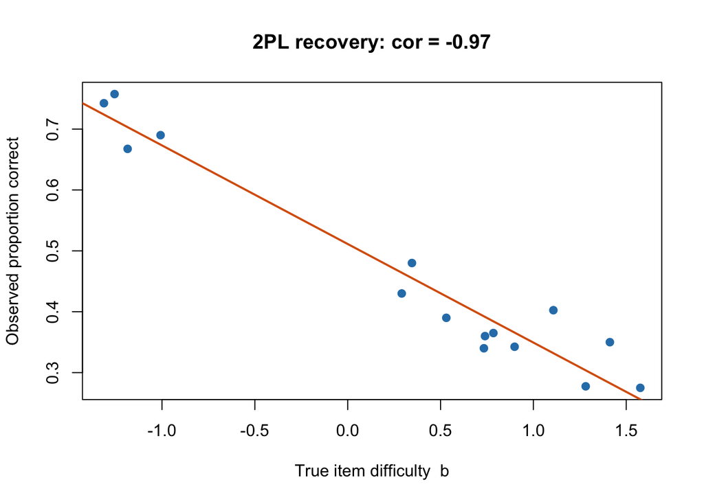

```r
plot(fit_2pl$params$b, prop_correct,
     pch = 19, col = "#2c7fb8",
     xlab = "True item difficulty  b",
     ylab = "Observed proportion correct",
     main = sprintf("2PL recovery: cor = %.2f",
                    cor(prop_correct, fit_2pl$params$b)))
abline(lm(prop_correct ~ fit_2pl$params$b), col = "#d95f0e", lwd = 2)
```

## Optional: estimating with `mirt`

When the `mirt` package is installed, the simulated data can be fit to confirm the generating parameters are recoverable by an external estimator. This chunk is skipped if `mirt` is not available.

```r
mod <- mirt::mirt(as.data.frame(fit_2pl), 1, itemtype = "2PL", verbose = FALSE)
est_b <- mirt::coef(mod, simplify = TRUE, IRTpars = TRUE)$items[, "b"]
cor(est_b, fit_2pl$params$b)     # estimated vs. true difficulty
```

```
#> [1] 0.9882692
```